# Creating the `rhasdata` R package

## Package setup

We start by specifying the information needed in the DESCRIPTION file of the R package.

```r
usethis::create_package(
  path = ".",
  fields = list(
    Package = params$package_name,
    Version = "0.0.0.9000",
    Title = "A Package That Has Data",
    Description = "This package has a dataset.  It could also have some functions, but for now all it has is some data.",
    `Authors@R` = person(
      given = "First",
      family = "Last",
      email = "you@gmail.com",
      role = c("aut", "cre")
      )
  )
)
usethis::use_mit_license(copyright_holder = "F. Last")
```

## Now to the package itself

### Create a data set

We will start with an example in which our data is simply created by code (which might include code to download data from some site).

The *R Packages (2e) book* [suggests](https://r-pkgs.org/data.html#sec-data-data-raw) including a `data-raw` directory in our R package to document any processing that might have occurred. Of course, if you make this .Rmd file publicly available (which we recommend!), then this would be a documentation of all processing. However, we show here how to put the data processing code in the package itself. We start by creating the directory `data-raw`:

```r
fs::dir_create("data-raw")
```

We send our processing to a code file called `create_mydata.R` in the directory we just created by using `send_to = "data-raw/create_mydata.R"`:

```r
set.seed(123)
n <- 100
x <- rnorm(n)
y <- 2 * x + 0.3 * rnorm(n)
mydata <- data.frame(x = x, y = y)
```

Let’s have a look:

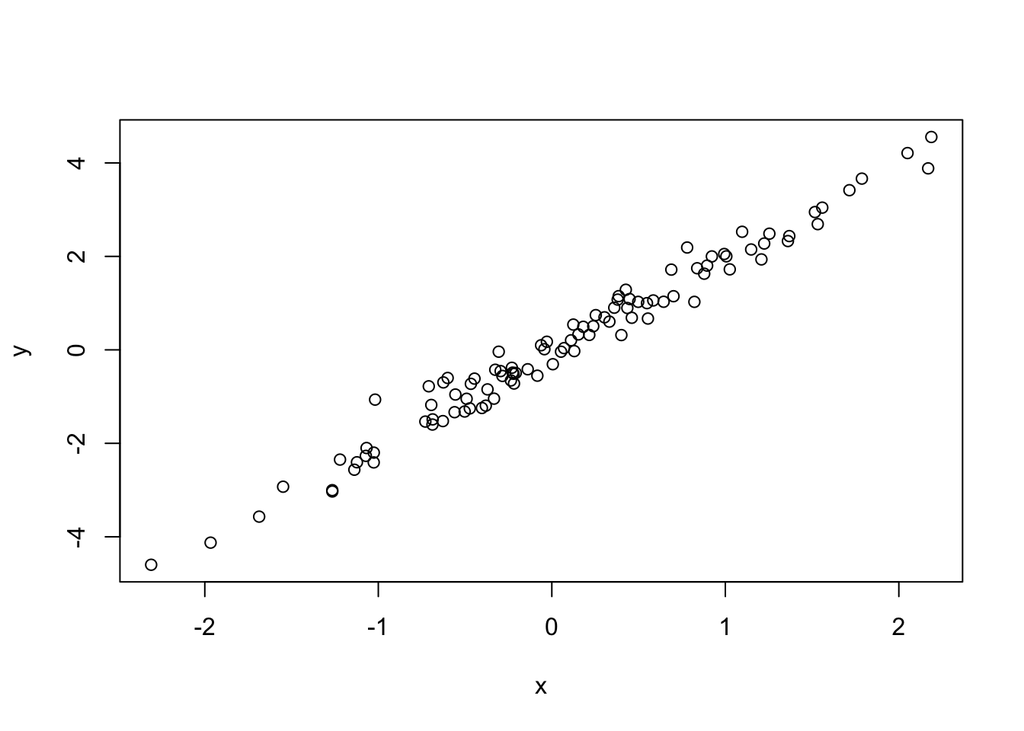

```r
plot(y ~ x, data = mydata)
```

Now, let’s send this off to the package:

```r
usethis::use_data(mydata)
```

```
## ✔ Adding R to 'Depends' field in DESCRIPTION.
```

```
## ✔ Creating 'data/'.
```

```
## ✔ Setting 'LazyData' to "true" in 'DESCRIPTION'.
```

```
## ✔ Saving "mydata" to "data/mydata.rda".
```

```
## ☐ Document your data (see <https://r-pkgs.org/data.html>).
```

And we’ll need to document the data set as well:

```r
#' A regression data set
#'
#' @format A data frame with 100 rows and 2 variables:
#' \describe{
#' \item{x}{a predictor variable}
#' \item{y}{a response variable}
#' }
#' @source This data was simulated.  But usually we might cite a source here.
"mydata"
```

```
## [1] "mydata"
```

### What if you have a local data file that you want to include?

Suppose you have a file called `my-raw-data.csv` in the directory `source-files/` that you’d like to include in your package, perhaps after some processing. Then you can copy that file into your R package’s `data-raw/` directory:

```r
fs::file_copy("../source-files/my-raw-data.csv", "data-raw/")
```

Then you could document in `data-raw/` whatever manipulation you want before including this in the package:

```r
ages <- read.csv("data-raw/my-raw-data.csv")
ages <- data.frame(id = seq_len(nrow(ages)), age = ages$ages)
usethis::use_data(ages)
```

```
## ✔ Saving "ages" to "data/ages.rda".
```

```
## ☐ Document your data (see <https://r-pkgs.org/data.html>).
```

Finally, you would document the object as we did in the previous example:

```r
#' An ages data set
#'
#' @format A data frame with ages of people.
#' \describe{
#' \item{id}{id of person}
#' \item{age}{age of person}
#' }
#' @source This data came from `my-raw-data.csv`
"ages"
```

```
## [1] "ages"
```

As noted in the link to the book above, we might also want to add the `data-raw/` directory to `.Rbuildignore` so that it is not included in the bundled version of the package. This can be accomplished as follows:

```r
cat("^data-raw$", file = ".Rbuildignore", append = TRUE, fill = TRUE)
```

## Documenting the package and building

We finish by running commands that will document, build, and install the package. It may also be a good idea to check the package from within this file.

```r
litr::document() # <-- use instead of devtools::document()
# devtools::build()
# devtools::install()
# devtools::check(document = FALSE)
```

```
## ℹ Updating rhasdata documentation
## ℹ Setting Config/roxygen2/version to "8.1.0"
## ℹ Loading rhasdata
## Writing 'ages.Rd'
## Writing 'mydata.Rd'
```